# Analyzing Individual BGG Users

Phil Henrickson

2022-01-02

# **mmrempen’s** BoardGameGeek Collection

This notebook contains a set of analyses for the selected user’s boardgamegeek collection. The bulk of the analysis is focused on building a user-specific predictive model to predict the games that mmrempen is likely to own. This enables to ask questions like, based on the games the user currently owns, what games are a good fit for their collection? What upcoming games are they likely to purchase?

This analysis is based on data from BoardGameGeek that was last updated on **2021-12-20.**

# 1 Collection Overview

We can look at a basic description of the number of games that the user owns, has rated, has previously owned, etc.

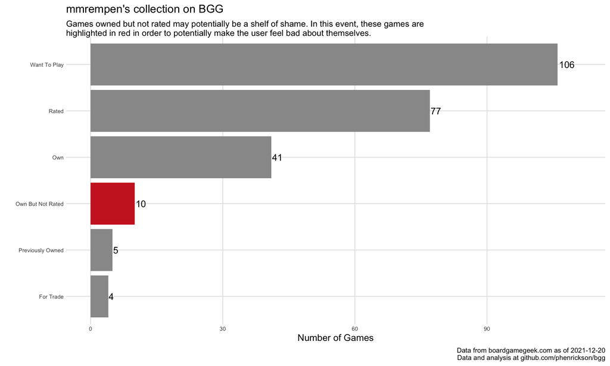

What years has the user owned/rated games from? While we can’t see when a user added or removed a game from their collection, we can look at their collection by the years in which their games were published.

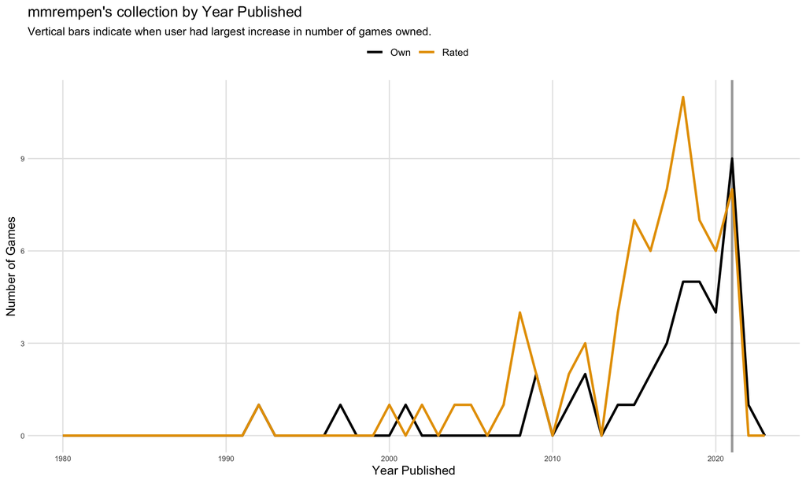

## 1.1 What types of games does mmrempen own?

We can look at the most frequent types of categories, mechanics, designers, and artists that appear in a user’s collection.

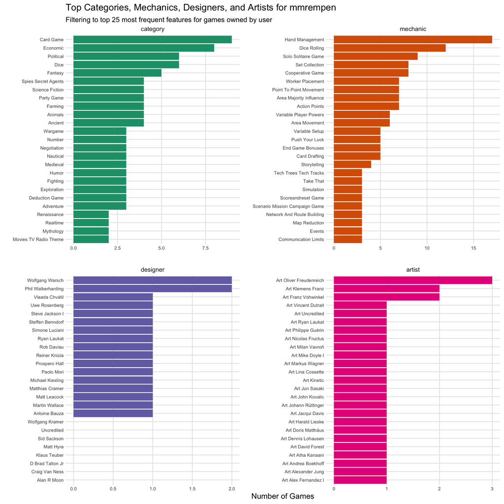

# 2 Modeling **mmrempen’s** Collection

| username | dataset | period | games_owned | games_rated | games_played |
| --- | --- | --- | --- | --- | --- |
| mmrempen | training | published before 2020 | 27 | 63 | 68 |
| mmrempen | test | published 2020 or later | 14 | 14 | 19 |

There are two main (binary) outcomes we will be modeling for the user.

The first, **own** refers to whether the user currently lists a game as owned in their collection. The second, **played** refers to whether the user currently owns, has rated, or previously owned a game. This means the latter will generally have a larger list of games, but may still be a useful category to examine for people who play lots of games without necessarily owning them.

We will train predictive models to learn the probability that the user will own or play individual games based on their features.

## 2.1 Coefficients for mmrempen

We can examine coefficients from the trained modes, which are penalized logistic regressions fit to our two main outcomes. Positive values indicate that a feature increases a user’s probabilility of owning/rating a game, while negative values indicate a feature decreases the probability.

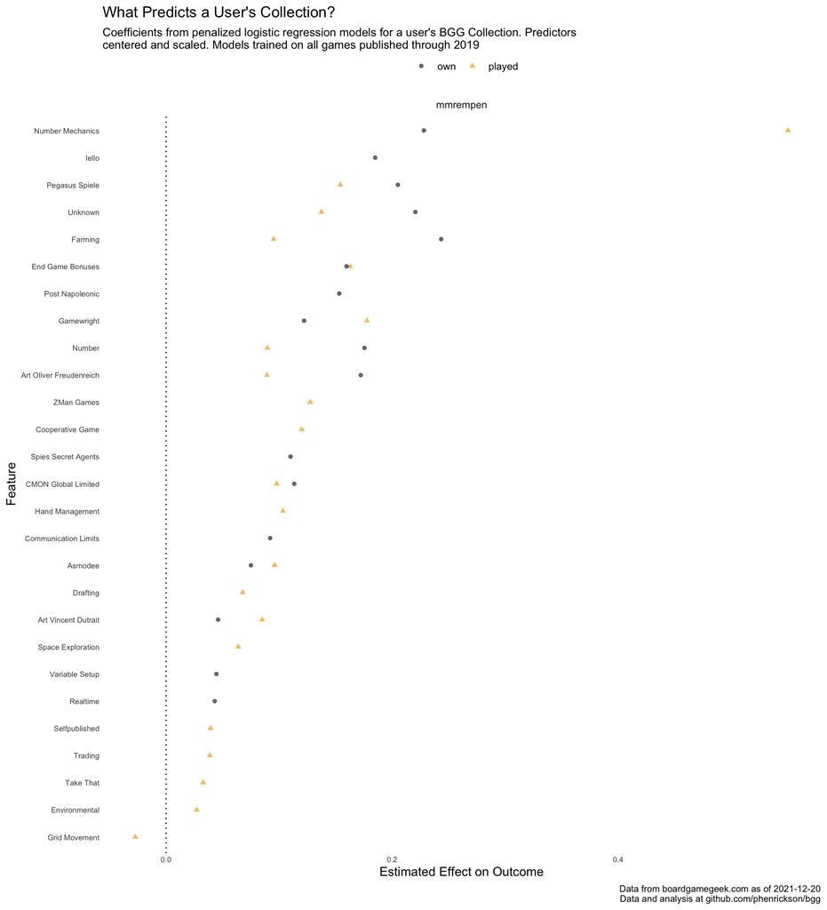

## 2.2 Visualizing Predictors for mmrempen’s Collection

Why did the model identify these features? We can make density plots of the important features for predicting whether the user owned a game. Blue indicates the density for games owned by the user, while grey indicates the density for games not owned by the user.

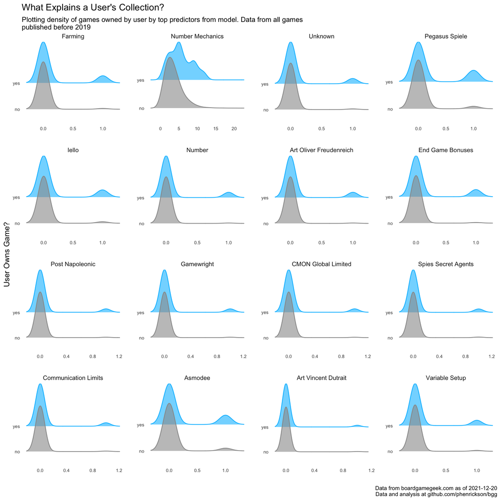

Binary predictors can be difficult to see with this visualization, so we can also directly examine the percentage of games in a user’s collection with a predictor vs the percentage of all games with that predictor.

| username | Feature | % of Games with Feature In_Collection | % of Games with Feature All_Games | Ratio |
| --- | --- | --- | --- | --- |
| mmrempen | Number | 11.1% | 0.9% | 12.5 |
| mmrempen | End Game Bonuses | 14.8% | 1.3% | 11.8 |
| mmrempen | CMON Global Limited | 7.4% | 0.8% | 9.1 |
| mmrempen | Farming | 14.8% | 1.7% | 8.9 |
| mmrempen | Post Napoleonic | 7.4% | 0.9% | 8.3 |
| mmrempen | Gamewright | 7.4% | 0.9% | 7.8 |
| mmrempen | Unknown | 11.1% | 1.5% | 7.6 |
| mmrempen | Communication Limits | 7.4% | 1.0% | 7.5 |
| mmrempen | Contracts | 7.4% | 1.0% | 7.2 |
| mmrempen | Variable Setup | 11.1% | 1.9% | 5.9 |
| mmrempen | Spies Secret Agents | 7.4% | 1.3% | 5.7 |
| mmrempen | Realtime | 3.7% | 0.7% | 5.3 |
| mmrempen | Iello | 14.8% | 3.1% | 4.8 |
| mmrempen | Pegasus Spiele | 22.2% | 4.7% | 4.7 |
| mmrempen | Asmodee | 18.5% | 5.4% | 3.4 |
| mmrempen | Acting | 3.7% | 1.1% | 3.4 |
| mmrempen | Transportation | 7.4% | 2.7% | 2.7 |
| mmrempen | Economic | 22.2% | 10.0% | 2.2 |
| mmrempen | Hand Management | 44.4% | 26.7% | 1.7 |
| mmrempen | Deduction Game | 0.0% | 6.5% | 0.0 |
| mmrempen | Simultaneous Action Selection | 0.0% | 7.2% | 0.0 |
| mmrempen | Variable Phase Order | 0.0% | 2.1% | 0.0 |
| mmrempen | City Building | 0.0% | 4.3% | 0.0 |
| mmrempen | Horror | 0.0% | 4.0% | 0.0 |
| mmrempen | Word Game | 0.0% | 1.8% | 0.0 |

# 3 Assess Model’s Performance on Training Set

Before predicting games in upcoming years, we can examine how well the model did and what games it liked in the training set. In this case, we used resampling techniques (cross validation) to ensure that the model had not seen a game before making its predictions.

## 3.1 Separation Plot

An easy way to examine the performance of classification model is to view a separation plot. We plot the predicted probabilities from the model for every game (from resampling) from lowest to highest. We then overlay a blue line for any game that the user does own. A good classifier is one that is able to *separate* the blue (games owned by the user) from the white (games not owned by the user), with most of the blue occurring at the highest probabilities (right side of the chart).

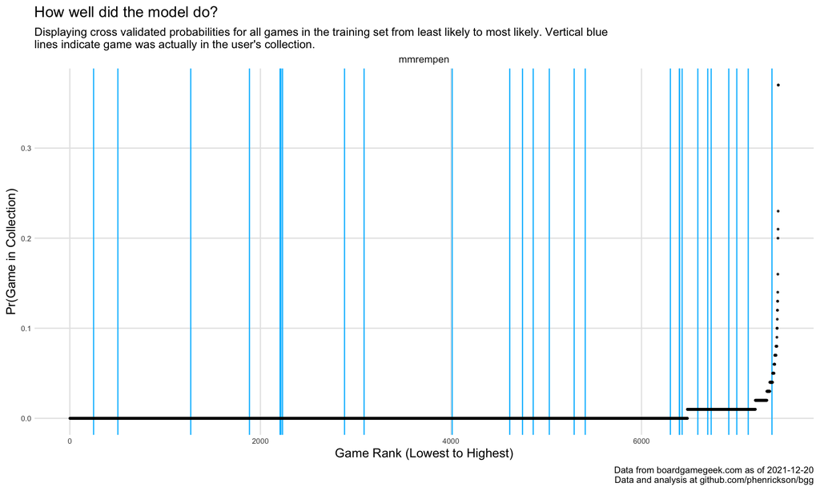

## 3.2 Top Games for **mmrempen** from Training Set

We can display this information in table form, displaying the 100 games with the highest probability of ownership, adding a blue line when the user does own the game.

| username | yearpublished | game_id | name | pred_played | pred_own | actual_played | actual_own |
| --- | --- | --- | --- | --- | --- | --- | --- |
| mmrempen | 2018 | 244711 | Newton | 0.66 | 0.37 | 0 | 0 |
| mmrempen | 2006 | 22864 | Zeus on the Loose | 0.06 | 0.37 | 0 | 0 |
| mmrempen | 2018 | 205896 | Rising Sun | 0.90 | 0.23 | 1 | 0 |
| mmrempen | 2013 | 52461 | Legacy: The Testament of Duke de Crecy | 0.12 | 0.21 | 0 | 0 |
| mmrempen | 2015 | 173090 | The Game | 0.02 | 0.20 | 0 | 0 |
| mmrempen | 2019 | 270673 | Silver & Gold | 0.05 | 0.16 | 0 | 0 |
| mmrempen | 2004 | 9216 | Goa | 0.12 | 0.14 | 0 | 0 |
| mmrempen | 1977 | 811 | Rummikub | 0.03 | 0.13 | 0 | 0 |
| mmrempen | 2007 | 29937 | König von Siam | 0.05 | 0.13 | 0 | 0 |
| mmrempen | 1930 | 8784 | Po-Ke-No | 0.01 | 0.12 | 0 | 0 |
| mmrempen | 2013 | 141517 | A Study in Emerald | 0.02 | 0.12 | 0 | 0 |
| mmrempen | 2014 | 153938 | Camel Up | 0.07 | 0.11 | 1 | 0 |
| mmrempen | 2015 | 169794 | Haspelknecht | 0.04 | 0.10 | 0 | 0 |
| mmrempen | 2017 | 216132 | Clans of Caledonia | 0.04 | 0.10 | 0 | 0 |
| mmrempen | 2008 | 34375 | Go Nuts! | 0.02 | 0.10 | 0 | 0 |
| mmrempen | 1900 | 11670 | The Game of Authors | 0.02 | 0.09 | 0 | 0 |
| mmrempen | 2017 | 224037 | Codenames: Duet | 0.01 | 0.08 | 0 | 0 |
| mmrempen | 2015 | 180198 | Rolling America | 0.04 | 0.08 | 0 | 0 |
| mmrempen | 2015 | 175878 | 504 | 0.24 | 0.08 | 0 | 0 |
| mmrempen | 1982 | 2511 | Sherlock Holmes Consulting Detective: The Thames Murders & Other Cases | 0.02 | 0.08 | 0 | 0 |
| mmrempen | 2015 | 178900 | Codenames | 0.01 | 0.08 | 0 | 0 |
| mmrempen | 2016 | 198773 | Codenames: Pictures | 0.01 | 0.08 | 0 | 0 |
| mmrempen | 2019 | 265736 | Tiny Towns | 0.60 | 0.08 | 0 | 0 |
| mmrempen | 2018 | 248861 | Metro X | 0.09 | 0.08 | 0 | 0 |
| mmrempen | 1990 | 2944 | Halli Galli | 0.05 | 0.08 | 0 | 0 |
| mmrempen | 2017 | 227789 | Heaven & Ale | 0.05 | 0.07 | 0 | 0 |
| mmrempen | 2015 | 180593 | The Bloody Inn | 0.04 | 0.07 | 0 | 0 |
| mmrempen | 2013 | 95527 | Madeira | 0.02 | 0.07 | 0 | 0 |
| mmrempen | 2007 | 28720 | Brass: Lancashire | 0.02 | 0.07 | 0 | 0 |
| mmrempen | 2009 | 39683 | At the Gates of Loyang | 0.09 | 0.07 | 0 | 0 |

[output cut: 70 more lines]

We can also more formally assess how well the model did in resampling by looking at the area under the receiver operating characteristic. A perfect model would receive a score of 1, while a model that cannot predict the outcome will default to a score of 0.5. The extent to which something is a *good* score depends on the setting, but generally anything in the .8 to .9 range is very good while the .7 to .8 range is perfectly acceptable.

| username | outcome_type | .metric | .estimator | .estimate |
| --- | --- | --- | --- | --- |
| mmrempen | own | roc_auc | binary | 0.654 |
| mmrempen | played | roc_auc | binary | 0.853 |

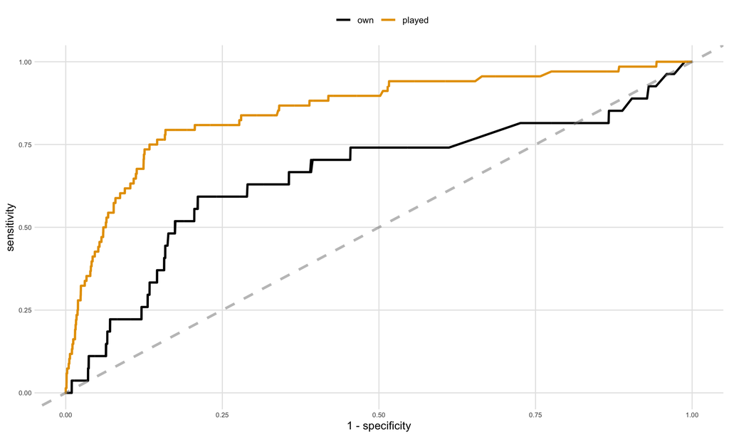

Another way to think about the model performance is to view its lift, or its ability to detect the positive outcomes over that of a null model. High lift indicates the model can much more quickly find all of the positive outcomes (in this case, games owned or played by the user), while a model with no lift is no better than random guessing.

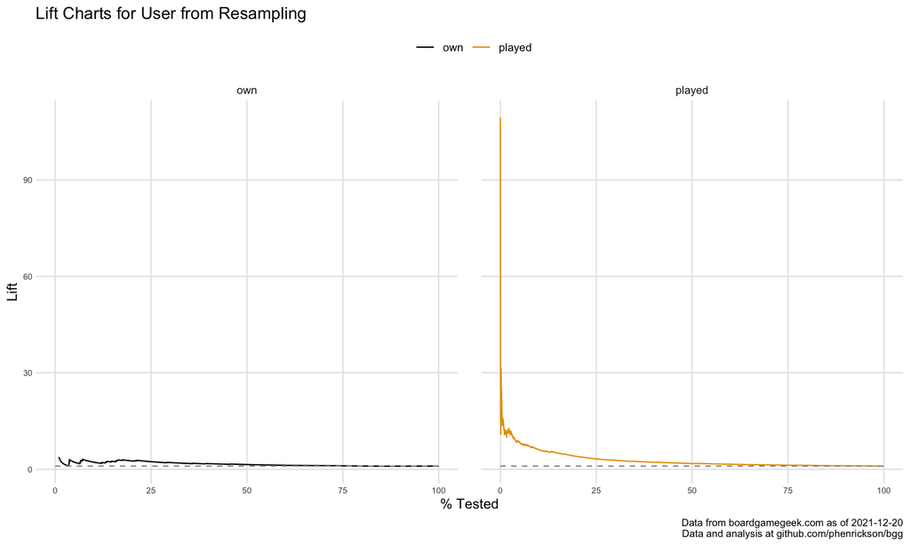

## 3.3 Most and Least Likely Games

What games does the model think mmrempen is **most likely to own** that are **not** in their collection?

| username | yearpublished | game_id | name | pred_own | actual_own |
| --- | --- | --- | --- | --- | --- |
| mmrempen | 2018 | 244711 | Newton | 0.37 | 0 |
| mmrempen | 2006 | 22864 | Zeus on the Loose | 0.37 | 0 |
| mmrempen | 2018 | 205896 | Rising Sun | 0.23 | 0 |
| mmrempen | 2013 | 52461 | Legacy: The Testament of Duke de Crecy | 0.21 | 0 |
| mmrempen | 2015 | 173090 | The Game | 0.20 | 0 |

What games does the model think mmrempen is **least likely to own** that **are** in their collection?

| username | yearpublished | game_id | name | pred_own | actual_own |
| --- | --- | --- | --- | --- | --- |
| mmrempen | 2019 | 274364 | Watergate | 0 | 1 |
| mmrempen | 2009 | 54043 | Jaipur | 0 | 1 |
| mmrempen | 2018 | 237182 | Root | 0 | 1 |
| mmrempen | 2019 | 272738 | Jaws | 0 | 1 |
| mmrempen | 2017 | 223953 | Kitchen Rush | 0 | 1 |

## 3.4 Top Games by Year

Top 25 games most likely to be owned by the user in each year, highlighting in blue the games that the user has owned/played.

| rank | 2011 | 2012 | 2013 | 2014 | 2015 | 2016 | 2017 | 2018 | 2019 |
| --- | --- | --- | --- | --- | --- | --- | --- | --- | --- |
| 1 | Village | Targi | Legacy: The Testament of Duke de Crecy | Camel Up | The Game | Codenames: Pictures | Clans of Caledonia | Newton | Silver & Gold |
| 2 | Mondo | Pax Porfiriana | A Study in Emerald | Qwixx Card Game | Haspelknecht | X nimmt! | Codenames: Duet | Rising Sun | Tiny Towns |
| 3 | Rory's Story Cubes: Voyages | Divided Republic | Madeira | Spyfall | Rolling America | Sherlock Holmes Consulting Detective: Jack the Ripper & West End Adventures | Heaven & Ale | Metro X | Maracaibo |
| 4 | Dungeon Fighter | Agricola: All Creatures Big and Small | Dicht dran | Deception: Murder in Hong Kong | 504 | When I Dream | The Shipwreck Arcana | Coimbra | Era: Medieval Age |
| 5 | Steam Torpedo: First Contact | Mondo Sapiens | Smash Up: Awesome Level 9000 | Fields of Arle | Codenames | 13 Days: The Cuban Missile Crisis | Magic Maze | Everdell | The Magnificent |
| 6 | Drako: Dragon & Dwarves | Freedom: The Underground Railroad | UGO! | Three Kingdoms Redux | The Bloody Inn | Beyond Baker Street | Santa Maria | Kero | Barrage |
| 7 | Streams | Lucky Numbers | Colonialism | Spurs: A Tale in the Old West | Grand Austria Hotel | Avenue | Gloomhaven | Underwater Cities | Clank!: Legacy – Acquisitions Incorporated |
| 8 | Principato | Keyflower | Caverna: The Cave Farmers | Smash Up: Monster Smash | Qwinto | Smash Up: It's Your Fault! | The Game: Face to Face | Cahoots | Yinzi |
| 9 | Dungeon Petz | Tokaido | Forbidden Desert | Castles of Mad King Ludwig | Me Want Cookies! | Cottage Garden | Muse | Gingerbread House | Sierra West |
| 10 | Santiago de Cuba | Urbion | Sushi Go! | Prime Climb | Raptor | Agricola (Revised Edition) | Smash Up: Big in Japan | Smash Up: That '70s Expansion | Yōkai |
| 11 | Ninjato | Suburbia | Smash Up: The Obligatory Cthulhu Set | Red7 | Mombasa | Captain Sonar | Caverna: Cave vs Cave | Penny Papers Adventures: The Valley of Wiraqocha | Ragusa |
| 12 | Saga | Il Vecchio | One Zero One | La Granja | Blood Rage | Codenames: Deep Undercover | Gaia Project | Tales of the Northlands: The Sagas of Noggin the Nog | Imperial Settlers: Empires of the North |
| 13 | Mage Knight Board Game | Santa Cruz | Rockwell | Yardmaster Express | Above and Below | Inis | Harvest Dice | Monolith Arena | Nanty Narking |
| 14 | Takenoko | Sheepland | Theseus: The Dark Orbit | Heroes of Normandie | Far Space Foundry | Yokohama | Massive Darkness | Blue Lagoon | Kitchen Rush (Revised Edition) |
| 15 | Pergamon: Second Edition | Zombicide | Sail to India | The Battle of Five Armies | Mysterium | Islebound | Lovecraft Letter | Azul: Stained Glass of Sintra | Azul: Summer Pavilion |
| 16 | My Happy Farm | Space Cadets | Patchistory | Smash Up: Science Fiction Double Feature | The Grizzled | Pandemic: Iberia | Sticky Chameleons | Pandoria | Pipeline |
| 17 | TSCHAK! | Yedo | Rory's Story Cubes: Prehistoria | Patchwork | The U.S. Civil War | Scythe | Fast Forward: FEAR | Western Legends | On Tour |
| 18 | Tragedy Looper | Terra Mystica | Gear & Piston | Star Realms | Smash Up: Pretty Pretty Smash Up | Smash Up: Cease and Desist | 13 Minutes: The Cuban Missile Crisis, 1962 | The World of SMOG: Rise of Moloch | HEXplore It: The Forests of Adrimon |
| 19 | Letters from Whitechapel | Mage Wars Arena | Kobayakawa | Onitama | Trambahn | Mr. Cabbagehead's Garden | LYNGK | Treasure Island | Zombicide: Invader |
| 20 | A Game of Thrones: The Board Game (Second Edition) | Polis: Fight for the Hegemony | Brew Crafters | Ninja Taisen | Holmes: Sherlock & Mycroft | Hit Z Road | Smash Up: What Were We Thinking? | A Song of Ice & Fire: Tabletop Miniatures Game – Stark vs Lannister Starter Set | Zombicide: Dark Side |
| 21 | King of Tokyo | Tzolk'in: The Mayan Calendar | Cinque Terre | KLASK | Tides of Time | Aeon's End | Fog of Love | Imhotep: The Duel | Revolution of 1828 |
| 22 | Nile DeLuxor | Legends of Andor | Navajo Wars | Rolling Japan | Star Realms: Colony Wars | Clank!: A Deck-Building Adventure | First Martians: Adventures on the Red Planet | At Any Cost: Metz 1870 | Foothills |
| 23 | Munchkin Axe Cop | War of the Ring: Second Edition | Cube Quest | The Ancient World | Brick Party | Great Western Trail | The King's Will | Blossoms | Naga Raja |
| 24 | Kabuki | Farmerama | Agent Hunter | Imperial Settlers | Spirits of the Rice Paddy | Mutant Crops | Exit: The Game – The Forgotten Island | Seasons of Rice | Mandala |
| 25 | Tem-Purr-A | Garden Dice | Longhorn | Orléans | I, Spy | The Oracle of Delphi | Riverboat | Orchard: A 9 card solitaire game | Unmatched: Robin Hood vs. Bigfoot |

## 3.5 Interactive Predictions from Resampling

Interactive table for predictions from resampling.

|  | username | yearpublished | rank | game_id | name | pred_played | pred_own | actual_played | actual_own |
| --- | --- | --- | --- | --- | --- | --- | --- | --- | --- |
| 1 | mmrempen | 1900 | 16 | 11670 | The Game of Authors | 0.02 | 0.09 | 0 | 0 |
| 2 | mmrempen | 1900 | 66 | 7316 | Bingo | 0.09 | 0.04 | 0 | 0 |
| 3 | mmrempen | 1900 | 110 | 15549 | Roulette | 0.01 | 0.03 | 0 | 0 |
| 4 | mmrempen | 1900 | 111 | 15878 | Rummy | 0.03 | 0.03 | 0 | 0 |
| 5 | mmrempen | 1900 | 113 | 10799 | Old Maid | 0.16 | 0.03 | 0 | 0 |
| 6 | mmrempen | 1900 | 172 | 2093 | Mahjong | 0.01 | 0.02 | 0 | 0 |
| 7 | mmrempen | 1900 | 216 | 2785 | Game of Goose | 0.04 | 0.02 | 0 | 0 |
| 8 | mmrempen | 1900 | 243 | 11901 | Tic-Tac-Toe | 0.01 | 0.01 | 0 | 0 |
| 9 | mmrempen | 1900 | 246 | 188 | Go | 0.01 | 0.01 | 0 | 0 |
| 10 | mmrempen | 1900 | 257 | 171 | Chess | 0.01 | 0.01 | 0 | 0 |

[output cut: 7426 more lines]

# 4 Validating the Model on 2020

How well did a model trained on a user’s collection through 2019 perform in predicting games for the user from 2020?

| username | outcome_type | yearpublished | .metric | .estimator | .estimate |
| --- | --- | --- | --- | --- | --- |
| mmrempen | own | 2020 | roc_auc | binary | 0.849 |
| mmrempen | played | 2020 | roc_auc | binary | 0.898 |

Table of top 25 games from 2020, highlighting games that the user owns.

| username | yearpublished | game_id | name | pred_own | pred_played | actual_own | actual_played |
| --- | --- | --- | --- | --- | --- | --- | --- |
| mmrempen | 2020 | 300322 | Hallertau | 0.43 | 0.21 | 0 | 0 |
| mmrempen | 2020 | 296512 | The Game: Quick & Easy | 0.06 | 0.03 | 0 | 0 |
| mmrempen | 2020 | 184267 | On Mars | 0.03 | 0.57 | 0 | 0 |
| mmrempen | 2020 | 270636 | My Farm Shop | 0.03 | 0.01 | 0 | 0 |
| mmrempen | 2020 | 288513 | Tranquility | 0.03 | 0.03 | 0 | 0 |
| mmrempen | 2020 | 302260 | Abandon All Artichokes | 0.03 | 0.03 | 0 | 0 |
| mmrempen | 2020 | 311193 | Anno 1800 | 0.03 | 0.02 | 0 | 0 |
| mmrempen | 2020 | 245224 | La Belle Époque | 0.02 | 0.01 | 0 | 0 |
| mmrempen | 2020 | 256317 | Guild Master | 0.02 | 0.34 | 0 | 0 |
| mmrempen | 2020 | 291457 | Gloomhaven: Jaws of the Lion | 0.02 | 0.23 | 0 | 0 |
| mmrempen | 2020 | 291508 | Tiny Epic Dinosaurs | 0.02 | 0.01 | 0 | 0 |
| mmrempen | 2020 | 306481 | Tawantinsuyu: The Inca Empire | 0.02 | 0.07 | 0 | 0 |
| mmrempen | 2020 | 308765 | Praga Caput Regni | 0.02 | 0.06 | 0 | 0 |
| mmrempen | 2020 | 318983 | Faiyum | 0.02 | 0.03 | 0 | 0 |
| mmrempen | 2020 | 177096 | Freedom! | 0.01 | 0.01 | 0 | 0 |
| mmrempen | 2020 | 227224 | The Red Cathedral | 0.01 | 0.06 | 0 | 0 |
| mmrempen | 2020 | 245658 | Unicorn Fever | 0.01 | 0.01 | 0 | 0 |
| mmrempen | 2020 | 245659 | Vampire: The Masquerade – Vendetta | 0.01 | 0.01 | 0 | 0 |
| mmrempen | 2020 | 246900 | Eclipse: Second Dawn for the Galaxy | 0.01 | 0.13 | 0 | 0 |
| mmrempen | 2020 | 252153 | Tang Garden | 0.01 | 0.02 | 0 | 0 |
| mmrempen | 2020 | 253506 | Versailles 1919 | 0.01 | 0.05 | 0 | 0 |
| mmrempen | 2020 | 254888 | High Rise | 0.01 | 0.02 | 0 | 0 |
| mmrempen | 2020 | 256940 | Krosmaster: Blast | 0.01 | 0.03 | 0 | 0 |
| mmrempen | 2020 | 256999 | Project: ELITE | 0.01 | 0.04 | 0 | 0 |
| mmrempen | 2020 | 257001 | Munchkin Dungeon | 0.01 | 0.01 | 0 | 0 |

# 5 Predicting Upcoming Games (2020 and On) for **mmrempen**

Examine the top games for the test set.

| username | yearpublished | game_id | name | rank | own | played |
| --- | --- | --- | --- | --- | --- | --- |
| mmrempen | 2020 | 300322 | Hallertau | 1 | 0.43 | 0.21 |
| mmrempen | 2020 | 296512 | The Game: Quick & Easy | 2 | 0.06 | 0.03 |
| mmrempen | 2020 | 270636 | My Farm Shop | 3 | 0.03 | 0.01 |
| mmrempen | 2020 | 311193 | Anno 1800 | 4 | 0.03 | 0.02 |
| mmrempen | 2020 | 184267 | On Mars | 5 | 0.03 | 0.57 |
| mmrempen | 2020 | 288513 | Tranquility | 6 | 0.03 | 0.03 |
| mmrempen | 2020 | 302260 | Abandon All Artichokes | 7 | 0.03 | 0.03 |
| mmrempen | 2020 | 291508 | Tiny Epic Dinosaurs | 8 | 0.02 | 0.01 |
| mmrempen | 2020 | 306481 | Tawantinsuyu: The Inca Empire | 9 | 0.02 | 0.07 |
| mmrempen | 2020 | 308765 | Praga Caput Regni | 10 | 0.02 | 0.06 |
| mmrempen | 2020 | 245224 | La Belle Époque | 11 | 0.02 | 0.01 |
| mmrempen | 2020 | 318983 | Faiyum | 12 | 0.02 | 0.03 |
| mmrempen | 2020 | 291457 | Gloomhaven: Jaws of the Lion | 13 | 0.02 | 0.23 |
| mmrempen | 2020 | 256317 | Guild Master | 14 | 0.02 | 0.34 |
| mmrempen | 2020 | 289939 | Goblin Teeth | 15 | 0.01 | 0.02 |
| mmrempen | 2020 | 262939 | Far Away | 16 | 0.01 | 0.02 |
| mmrempen | 2020 | 261449 | Sugar Blast | 17 | 0.01 | 0.01 |
| mmrempen | 2020 | 304420 | Bonfire | 18 | 0.01 | 0.01 |
| mmrempen | 2020 | 295488 | Andor: The Family Fantasy Game | 19 | 0.01 | 0.01 |
| mmrempen | 2020 | 295948 | Aqualin | 20 | 0.01 | 0.00 |
| mmrempen | 2020 | 306577 | Der Clou: Roll & Heist | 21 | 0.01 | 0.01 |
| mmrempen | 2020 | 297674 | Pacific Rails Inc. | 22 | 0.01 | 0.00 |
| mmrempen | 2020 | 293267 | Kitara | 23 | 0.01 | 0.01 |
| mmrempen | 2020 | 256940 | Krosmaster: Blast | 24 | 0.01 | 0.03 |
| mmrempen | 2020 | 293014 | Nidavellir | 25 | 0.01 | 0.01 |
| mmrempen | 2021 | 343905 | Boonlake | 1 | 0.20 | 0.25 |
| mmrempen | 2021 | 298102 | Roll Camera!: The Filmmaking Board Game | 2 | 0.07 | 0.26 |
| mmrempen | 2021 | 310873 | Carnegie | 3 | 0.06 | 0.39 |
| mmrempen | 2021 | 318084 | Furnace | 4 | 0.06 | 0.03 |
| mmrempen | 2021 | 345036 | Qwixx Longo | 5 | 0.05 | 0.02 |
| mmrempen | 2021 | 325698 | Juicy Fruits | 6 | 0.04 | 0.02 |
| mmrempen | 2021 | 299255 | Vienna Connection | 7 | 0.04 | 0.02 |
| mmrempen | 2021 | 332290 | Stardew Valley: The Board Game | 8 | 0.03 | 0.04 |
| mmrempen | 2021 | 284653 | Mind MGMT: The Psychic Espionage “Game.” | 9 | 0.03 | 0.02 |
| mmrempen | 2021 | 318184 | Imperium: Classics | 10 | 0.02 | 0.06 |
| mmrempen | 2021 | 319263 | One Card Dungeon | 11 | 0.02 | 0.10 |
| mmrempen | 2021 | 300217 | Merchants of the Dark Road | 12 | 0.02 | 0.09 |
| mmrempen | 2021 | 249277 | Brazil: Imperial | 13 | 0.02 | 0.09 |
| mmrempen | 2021 | 342942 | Ark Nova | 14 | 0.02 | 0.11 |
| mmrempen | 2021 | 285967 | Ankh: Gods of Egypt | 15 | 0.02 | 0.11 |
| mmrempen | 2021 | 335541 | We Care: a Grizzled Game | 16 | 0.02 | 0.05 |
| mmrempen | 2021 | 295681 | In Too Deep | 17 | 0.02 | 0.04 |
| mmrempen | 2021 | 336552 | Mystic Paths | 18 | 0.01 | 0.01 |
| mmrempen | 2021 | 341530 | Super Mega Lucky Box | 19 | 0.01 | 0.02 |
| mmrempen | 2021 | 291859 | Riftforce | 20 | 0.01 | 0.04 |
| mmrempen | 2021 | 338834 | MicroMacro: Crime City – Full House | 21 | 0.01 | 0.02 |
| mmrempen | 2021 | 323612 | Bitoku | 22 | 0.01 | 0.01 |
| mmrempen | 2021 | 304324 | Dive | 23 | 0.01 | 0.01 |
| mmrempen | 2021 | 295785 | Euthia: Torment of Resurrection | 24 | 0.01 | 0.05 |
| mmrempen | 2021 | 264164 | Night of the Living Dead: A Zombicide Game | 25 | 0.01 | 0.02 |
| mmrempen | 2022 | 304051 | Creature Comforts | 1 | 0.10 | 0.14 |
| mmrempen | 2022 | 326945 | Castles of Mad King Ludwig: Collector's Edition | 2 | 0.05 | 0.03 |
| mmrempen | 2022 | 317511 | Tindaya | 3 | 0.03 | 0.36 |
| mmrempen | 2022 | 319807 | Shogun no Katana | 4 | 0.02 | 0.06 |
| mmrempen | 2022 | 256680 | Return to Dark Tower | 5 | 0.01 | 0.04 |
| mmrempen | 2022 | 338067 | 6: Siege – The Board Game | 6 | 0.01 | 0.02 |
| mmrempen | 2022 | 322524 | Bardsung | 7 | 0.01 | 0.09 |
| mmrempen | 2022 | 311988 | Frostpunk: The Board Game | 8 | 0.01 | 0.03 |
| mmrempen | 2022 | 321608 | Hegemony: Lead Your Class to Victory | 9 | 0.01 | 0.02 |
| mmrempen | 2022 | 315610 | Massive Darkness 2: Hellscape | 10 | 0.01 | 0.03 |
| mmrempen | 2022 | 286158 | D.E.I.: Divide et Impera | 11 | 0.01 | 0.00 |
| mmrempen | 2022 | 295374 | Long Shot: The Dice Game | 12 | 0.01 | 0.03 |
| mmrempen | 2022 | 335427 | Wild: Serengeti | 13 | 0.01 | 0.04 |
| mmrempen | 2022 | 283137 | Human Punishment: The Beginning | 14 | 0.01 | 0.04 |
| mmrempen | 2022 | 336986 | Flamecraft | 15 | 0.01 | 0.03 |
| mmrempen | 2022 | 324090 | Scarface 1920 | 16 | 0.01 | 0.05 |
| mmrempen | 2022 | 293941 | Mage Noir | 17 | 0.01 | 0.01 |
| mmrempen | 2022 | 331106 | The Witcher: Old World | 18 | 0.01 | 0.10 |
| mmrempen | 2022 | 345868 | Federation | 19 | 0.01 | 0.02 |
| mmrempen | 2022 | 305096 | Endless Winter: Paleoamericans | 20 | 0.01 | 0.06 |
| mmrempen | 2022 | 280726 | Legacies | 21 | 0.01 | 0.09 |
| mmrempen | 2022 | 295770 | Frosthaven | 22 | 0.01 | 0.13 |
| mmrempen | 2022 | 155250 | TseuQuesT | 23 | 0.00 | 0.00 |
| mmrempen | 2022 | 274056 | HEL: The Last Saga | 24 | 0.00 | 0.00 |
| mmrempen | 2022 | 322354 | DEFCON 1 | 25 | 0.00 | 0.00 |

## 5.1 Interactive Table for Upcoming Games 2020 and On

|  | username | yearpublished | game_id | name | rank | own | played |
| --- | --- | --- | --- | --- | --- | --- | --- |
| 1 | mmrempen | 2020 | 300322 | Hallertau | 1 | 0.43 | 0.21 |
| 2 | mmrempen | 2021 | 343905 | Boonlake | 2 | 0.2 | 0.25 |
| 3 | mmrempen | 2022 | 304051 | Creature Comforts | 3 | 0.1 | 0.14 |
| 4 | mmrempen | 2021 | 298102 | Roll Camera!: The Filmmaking Board Game | 4 | 0.07 | 0.26 |
| 5 | mmrempen | 2020 | 296512 | The Game: Quick &amp; Easy | 5 | 0.06 | 0.03 |
| 6 | mmrempen | 2021 | 310873 | Carnegie | 6 | 0.06 | 0.39 |
| 7 | mmrempen | 2021 | 318084 | Furnace | 7 | 0.06 | 0.03 |
| 8 | mmrempen | 2022 | 326945 | Castles of Mad King Ludwig: Collector's Edition | 8 | 0.05 | 0.03 |
| 9 | mmrempen | 2021 | 345036 | Qwixx Longo | 9 | 0.05 | 0.02 |
| 10 | mmrempen | 2021 | 325698 | Juicy Fruits | 10 | 0.04 | 0.02 |

[output cut: 1627 more lines]